# STAT 420: Homework 1

D. Unger, Summer 2017

Due: Monday, June 19 by 11:50 PM CDT

# Directions

Students are encouraged to work together on homework using the discussion boards. However, sharing, copying or providing any part of a homework solution or code is an infraction of the University’s rules on Academic Integrity. Any violation will be punished as severely as possible.

- Your assignment must be submitted through the [submission link](https://compass2g.illinois.edu/webapps/assignment/uploadAssignment?content_id=_2646520_1&course_id=_31866_1&group_id=&mode=cpview) on **Compass 2g.** You are required to attach two (and only two) files to the *same* submission:
  - Your RMarkdown file which should be saved as `hw01_yourNetID.Rmd`. For example `hw01_dunger.Rmd`.
  - The result of knitting your RMarkdown file as `hw01_yourNetID.html`. For example `hw01_dunger.html`.
- To submit the two files, you must “zip” them together into a single `zip` file, and then submit that one file.
- Your resulting `.html` file will be considered a “report” which is the material that will determine the majority of your grade. Be sure to visibly include all `R` code and output that is relevant to answering the exercises. (You do not need to include irrelevant code you tried that resulted in error or did not answer the question correctly.)
- You are granted an unlimited number of submissions, but only the last submission *before* the deadline will be viewed and graded.
- If you use this `.Rmd` file as a template, be sure to remove the directions section, and consider removing `eval = FALSE` from any code chunks provided. (If you would like to run that code as part of your assignment.)
- Your `.Rmd` file should be written such that, if it is placed in a folder with any data your are asked to import, it will Knit properly without modification. (For this homework assignment, this will only be an issue for Exercise 5.)
- Unless otherwise stated, you may use `R` for each of the exercises.
- Be sure to read each exercise carefully!
- Include your Name and NetID in the final document, not only in your filenames.

# Assignment

## Exercise 1 (Basic `R`)

For this exercise, we will create several vectors and matrices, as well as perform various matrix operations.

**(a)** Create five vectors `x0`, `x1`, `x2`, `x3`, and `y`. Each should have a length of 25 and store the following:

- `x0`: Each element should be the value `1`.
- `x1`: The first 25 square numbers, starting from `1.` (So `1`, `4`, `9`, etc.)
- `x2`: 25 evenly spaced numbers between `0` and `1`. (Including `0` and `1`. It may help to read the documentation for `seq()`.)
- `x3`: The natural log of the integers from `1` to `25`.
- `y`: The result of running the following code, after creating the other four vectors:

```r
set.seed(42)
x0 = rep(1, 25)
x1 = seq(1, 25, by = 1)^2
x2 = seq(0, 1, length.out = 25)
x3 = log(seq(1, 25, by = 1))
y  = 5 * x0 + 1 * x1 + 6 * x2 + 3 * x3 + rnorm(25, 0 , 1)
print(sum(y))
```

```
## [1] 5903.699
```

Report the value returned from `sum(y)`.

**(b)** Create a matrix `X` which stores `x0`, `x1`, `x2`, and `x3` as columns of the matrix. Report the value returned from `sum(X)`.

```r
X <- as.matrix(cbind(x0, x1, x2, x3))
sum(X)
```

```
## [1] 5620.504
```

**(c)** Use matrix operations to create a new matrix `beta_hat` defined as follows:

$$\hat{\beta} = (X^T X)^{-1} X^T y.$$

Report the values stored in the matrix `beta_hat`. Note that you can use the vector `y` as if it is a $25 \times 1$ matrix.

```r
beta_hat = solve(t(X) %*% X) %*% t(X) %*% y
beta_hat
```

```
##         [,1]
## x0  5.197394
## x1  1.013258
## x2 -6.966652
## x3  4.527270
```

**(d)** Your `beta_hat` should store a $4 \times 1$ matrix. That is, a matrix with $4$ rows and $1$ column. Subset this matrix to exclude the first row, then square each element and report the sum of these results.

```r
beta_hat_subset = beta_hat[-1]
beta_hat_subset
```

```
## [1]  1.013258 -6.966652  4.527270
```

```r
sum(beta_hat_subset^2)
```

```
## [1] 70.05711
```

**(e)** Create a new variable `y_hat` which stores the result of the matrix operation,

$$\hat{y} = X \hat{\beta}.$$

The result will be a $25 \times 1$ matrix. Perform and report the result of the following operation,

$$\sum_{i = 1}^{25} (y_i - \hat{y}_i)^ 2.$$

Here you can use the matrix `y_hat` as if it is a vector. Then, $y_i$ is the $i$th element of $y$ and $\hat{y}_i$ is the $i$th element of $\hat{y}$.

```r
y_hat = X %*% beta_hat
sum((y_hat - y)^2)
```

```
## [1] 36.97258
```

## Exercise 2 (Discrete Probability)

The [2016 United States presidential election](https://en.wikipedia.org/wiki/United_States_presidential_election,_2016) was an interesting contest. Prior to the election, a [Fox News National Poll](http://www.foxnews.com/politics/interactive/2016/06/09/fox-news-poll-national-releas-6-16/) which surveyed 1004 registered voters placed former New Mexico Governor [Gary Johnson](https://en.wikipedia.org/wiki/Gary_Johnson) in third place polling in the double digits at 12%.

Suppose the true proportion of registered voters that support Johnson is 12% and we obtain our own random sample of 40 registered voters. Answer the follows questions as they relate to this sample of 40 voters.

**(a)** What is the probability that exactly 5 of the voters are Johnson supporters?

```r
dbinom(x = 5, size = 40, prob = 0.12)
```

```
## [1] 0.1866513
```

**(b)** What is the probability that 10 or fewer voters are Johnson supporters?

```r
pbinom(10, size = 40, prob = .12)
```

```
## [1] 0.9938466
```

**(c)** What is the probability that 37 or more voters are **not** Johnson supporters?

```r
pbinom(36, size = 40, prob = .88, lower.tail = FALSE)
```

```
## [1] 0.2768032
```

**(d)** What is the probability that between 3 and 9 (inclusive) voters are Johnson supporters?

```r
sum(dbinom(3:9, size = 40, prob = .12))
```

```
## [1] 0.8564221
```

```r
pbinom(9, size = 40, prob = .12) - pbinom(2, size = 40, prob = .12)
```

```
## [1] 0.8564221
```

## Exercise 3 (Continuous Probability)

For this exercise, consider a random variable $X$ which is normally distributed with a mean of 100 and a standard deviation of 15. That is,

$$X \sim N\left(\mu = 100, \sigma^2 = 225\right).$$

**(a)** Calculate $P(X < 90)$.

```r
pnorm(q = 90, mean = 100, sd = 15)
```

```
## [1] 0.2524925
```

**(b)** Calculate $P(X > 105)$.

```r
pnorm(q = 105, mean = 100, sd = 15, lower.tail = FALSE)
```

```
## [1] 0.3694413
```

**(c)** Calculate $P(95 < X < 100)$.

```r
pnorm(q = 100, mean = 100, sd = 15) - pnorm(q = 95, mean = 100, sd = 15)
```

```
## [1] 0.1305587
```

**(d)** Find $q$ such that $P(X < q) = 0.10$.

```r
qnorm(p = 0.1, mean = 100, sd = 15)
```

```
## [1] 80.77673
```

**(e)** Find $q$ such that $P(X > q) = 0.05$.

```r
qnorm(p = 0.05, mean = 100, sd = 15, lower.tail = FALSE)
```

```
## [1] 124.6728
```

## Exercise 4 (Writing Functions)

In this exercise we will write our own functions related to performing a one-sample $t$ test. That is $H_{0}: \mu = \mu_{0}$ versus $H_{1}: \mu \neq \mu_{0},$ where $\mu_{0}$ is the hypothesized value of $\mu$.

Throughout this exercise you may **not** use the `t.test()` function inside your functions. You may use it to check your work separately, but no such double-checks should appear in your final report.

Some built in `R` functions that may be useful to you when writing your functions include: `c()`, `ifelse()`, `mean()`, `sd()`, `abs()`, `length()`, `sqrt()`, and `pt()`.

**(a)** Write a function called `do_t_test` which takes two inputs:

- `x`: A vector which stores observations.
- `mu`: The hypothesized value of $\mu$ which defaults to `0`.

The function should output:

- The value of the test statistic, $t$.
- The p-value of the test. The function only needs to be able to handle a two-sided alternative.

In order to output both, consider using `c(t, pval)` as the last line of your function, and store those two values elsewhere in the body of your function.

```r
do_t_test <- function(x, mu = 0){
  n = length(x)
  t = (mean(x) - mu)/(sd(x)/sqrt(n))
  p_value = 2*pt(abs(t), df = n-1, lower.tail = FALSE)
  return(c(t, p_value))
}
```

**(b)** Write a function called `make_decision` which takes two inputs:

- `pval`: The p-value of a test.
- `alpha`: The significance level of a test. Set a default value of `0.05`.

The function should output `"Reject!"` or `"Fail to Reject."` based on the comparison of `pval` to `alpha`.

```r
make_decision <- function(pval, alpha=0.05){
  ifelse(pval < alpha, "Reject!", "Fail to Reject.")
}
```

**(c)** Now we will test the quality of your functions from parts **(a)** and **(b)**. Run the following code:

```r
set.seed(42)
y = rnorm(25, 1.4, 1)
pval = do_t_test(y, mu = 2)[2]
pval
```

```
## [1] 0.1275027
```

```r
make_decision(pval)
```

```
## [1] "Fail to Reject."
```

If your `do_t_test()` and `make_decision()` functions are correct, you should obtain a decision of `"Fail to Reject."` You will also be evaluated on whether the numeric p-value you obtain is correct.

## Exercise 5 (Importing Data, Plotting, Testing)

For this exercise we will use the data that is stored in `intelligence.csv` which records IQs of a random sample of residents of Pawnee and Eagleton, Indiana.

**(a)** Save `intelligence.csv` to your computer. Place it in a folder which also contains your `.Rmd` file. Load the data from `intelligence.csv` into a variable in `R` called `intelligence`. Show the code used to do this.

Note: If you use the “Import Dataset” feature in RStudio, a command to load the data into a variable called `intelligence` will be automatically placed in the Console window. This command will be correct, however, you should modify it to work any time your `.Rmd` file is in a folder that contains the file `intelligence.csv`.

```r
intelligence <- read.csv("intelligence.csv")
```

**(b)** Create a side-by-side boxplot that compares the IQs across the two towns. Be sure to give the plot a title and label the axes appropriately.

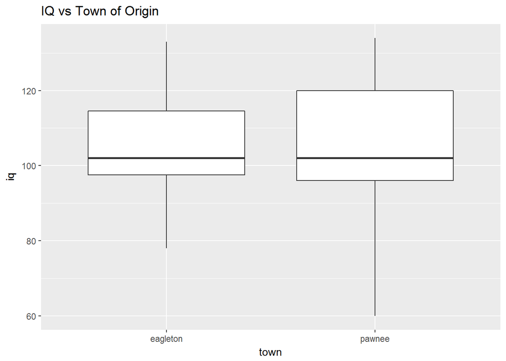

```r
library(ggplot2)
ggplot(data = intelligence) +
  geom_boxplot(mapping = aes(x = town,
                             y = iq)) +
  ggtitle("IQ vs Town of Origin")
```

**(c)** Are people from Eagleton smarter than people from Pawnee? Perform the appropriate statistical test using the given sample data. That is, test $H_0: \mu_E = \mu_P$ vs $H_1: \mu_E > \mu_P$, where

- $\mu_E$ is the mean IQ of a resident of Eagleton.
- $\mu_P$ is the mean IQ of a resident of Pawnee.

Explicitly state the p-value of the test and the resulting statistical decision at a significance level $\alpha = 0.10$. Interpret the results in the context of the problem.

```r
t.test(iq ~ town, data = intelligence, alternative = "greater", conf.level = .1, var.equal = FALSE)
```

```
##
##  Welch Two Sample t-test
##
## data:  iq by town
## t = 0.40949, df = 32.928, p-value = 0.3424
## alternative hypothesis: true difference in means is greater than 0
## 10 percent confidence interval:
##  10.20477      Inf
## sample estimates:
## mean in group eagleton   mean in group pawnee
##               105.3333               102.9000
```

## Exercise 6 (Packages, Plotting, Testing)

For this exercise, we will use the `diabetes` dataset from the `faraway` package.

**(a)** Install and load the `faraway` package. **Do not** include the install command in your .Rmd file. (If you do it will install the package every time you knit your file.) **Do** include the command to load the package into your environment.

```r
library(faraway)
```

**(b)** How many observations are in this dataset? How many variables?

```r
# data(diabetes)
dim(diabetes)
```

```
## [1] 403  19
```

**(c)** What are the names of the variables in this dataset?

```r
names(diabetes)
```

```
##  [1] "id"       "chol"     "stab.glu" "hdl"      "ratio"    "glyhb"
##  [7] "location" "age"      "gender"   "height"   "weight"   "frame"
## [13] "bp.1s"    "bp.1d"    "bp.2s"    "bp.2d"    "waist"    "hip"
## [19] "time.ppn"
```

**(d)** What is the mean [HDL](https://en.wikipedia.org/wiki/High-density_lipoprotein) level (High Density Lipoprotein) of individuals in this sample?

```r
mean(diabetes$hdl, na.rm = TRUE)
```

```
## [1] 50.44527
```

**(e)** What is the standard deviation total cholesterol of individuals in this sample?

```r
sd(diabetes$chol, na.rm = TRUE)
```

```
## [1] 44.44556
```

**(f)** What is the range of ages of individuals in this sample?

```r
range(diabetes$age, na.rm = TRUE)
```

```
## [1] 19 92
```

**(g)** What is the mean HDL of females in this sample? Hint: you will automatically check your answer in part **(j)**.

```r
mean(diabetes$hdl[which(diabetes$gender == "female")])
```

```
## [1] 52.11111
```

**(h)** Create a scatterplot of HDL (y-axis) vs weight (x-axis). Use a non-default color for the points. (Also, be sure to give the plot a title and label the axes appropriately.) Based on the scatterplot, does there seem to be a relationship between the two variables? Briefly explain.

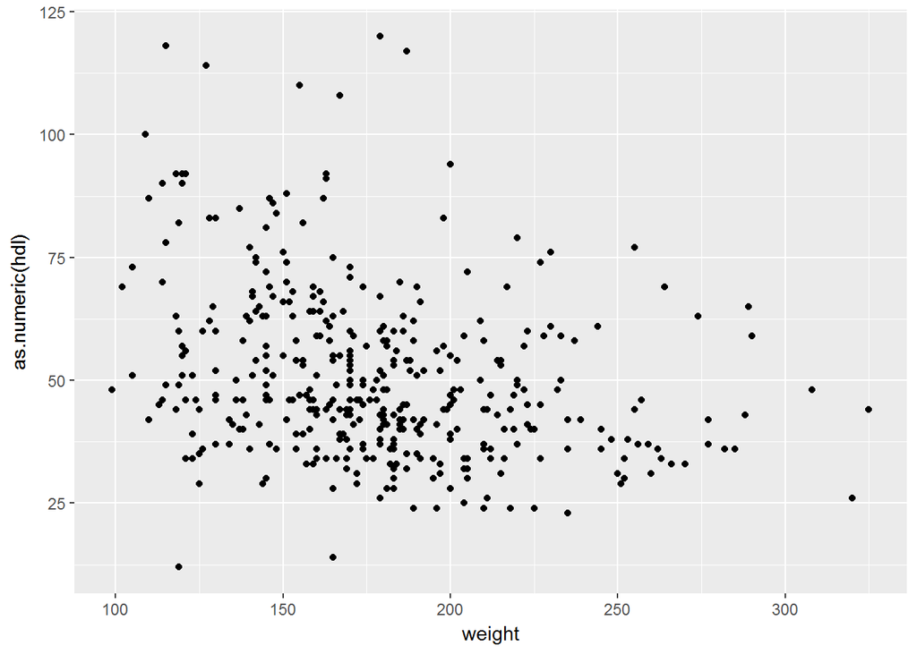

```r
ggplot(data = diabetes) +
  geom_point(mapping = aes(x = weight,
                           y = as.numeric(hdl)))
```

**(i)** Create a scatterplot of total cholesterol (y-axis) vs weight (x-axis). Use a non-default color for the points. (Also, be sure to give the plot a title and label the axes appropriately.) Based on the scatterplot, does there seem to be a relationship between the two variables? Briefly explain.

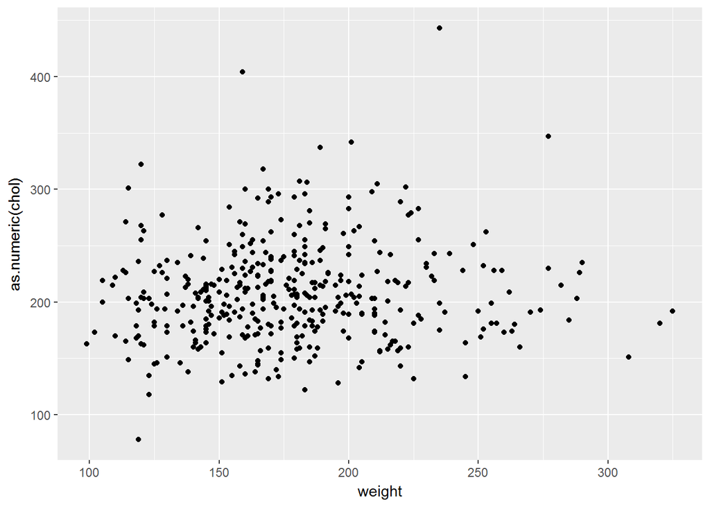

```r
ggplot(data = diabetes) +
  geom_point(mapping = aes(x = weight,
                           y = as.numeric(chol)))
```

**(j)** Do rural African American men and women have the same average HDL level? Perform the appropriate statistical test using the given sample data. That is, test $H_0: \mu_m = \mu_f$ vs $H_1: \mu_m \neq \mu_f$, where

- $\mu_m$ is the mean HDL of a rural African American male.
- $\mu_f$ is the mean HDL of a rural African American female.

Explicitly state the p-value of the test and the resulting statistical decision at a significance level $\alpha = 0.05$. Interpret the results in the context of the problem.

```r
t.test(hdl ~ gender, data = diabetes)
```

```
##
##  Welch Two Sample t-test
##
## data:  hdl by gender
## t = -2.3, df = 362.39, p-value = 0.02202
## alternative hypothesis: true difference in means is not equal to 0
## 95 percent confidence interval:
##  -7.3942765 -0.5779457
## sample estimates:
##   mean in group male mean in group female
##             48.12500             52.11111
```